# Credit Card Fraud Detection — Detecting Fraudulent Transactions

**Data:** Kaggle Credit Card Fraud Detection Dataset — 284,807 transactions, 28 PCA features, 0.17% fraud rate

**Problem:** Given 28 PCA-transformed features (V1–V28), transaction amount, and timestamp, predict whether a transaction is fraudulent (Class=1) or legitimate (Class=0).

```python
import pandas as pd
import numpy as np
import matplotlib.pyplot as plt
import seaborn as sns
from sklearn.model_selection import train_test_split
from sklearn.preprocessing import StandardScaler
from sklearn.linear_model import LogisticRegression
from sklearn.ensemble import RandomForestClassifier
from sklearn.metrics import (
    confusion_matrix, precision_recall_curve,
    average_precision_score, precision_score,
    recall_score, f1_score
)
import xgboost as xgb
import os.path

sns.set_style("whitegrid")
print("All imports loaded successfully")
```

```
All imports loaded successfully
```

```python
if not os.path.exists("data.csv"):
    print("=" * 60)
    print("DATA NOT FOUND - Download from Kaggle:")
    print("  https://www.kaggle.com/datasets/mlg-ulb/creditcardfraud")
    print("Place as 'data.csv' in this folder, then re-run.")
    print("=" * 60)
    raise FileNotFoundError("data.csv not found")

df = pd.read_csv("data.csv")
print(f"Dataset: {df.shape[0]:,} rows, {df.shape[1]} columns")
print(f"Memory usage: {df.memory_usage(deep=True).sum() / 1024**2:.1f} MB")
```

```
Dataset: 284,807 rows, 31 columns
Memory usage: 67.4 MB
```

```python
df.head(10)
```

|  | Time | V1 | V2 | V3 | V4 | V5 | V6 | V7 | V8 | V9 | ... | V21 | V22 | V23 | V24 | V25 | V26 | V27 | V28 | Amount | Class |
| --- | --- | --- | --- | --- | --- | --- | --- | --- | --- | --- | --- | --- | --- | --- | --- | --- | --- | --- | --- | --- | --- |
| 0 | 0.0 | -1.359807 | -0.072781 | 2.536347 | 1.378155 | -0.338321 | 0.462388 | 0.239599 | 0.098698 | 0.363787 | ... | -0.018307 | 0.277838 | -0.110474 | 0.066928 | 0.128539 | -0.189115 | 0.133558 | -0.021053 | 149.62 | 0 |
| 1 | 0.0 | 1.191857 | 0.266151 | 0.166480 | 0.448154 | 0.060018 | -0.082361 | -0.078803 | 0.085102 | -0.255425 | ... | -0.225775 | -0.638672 | 0.101288 | -0.339846 | 0.167170 | 0.125895 | -0.008983 | 0.014724 | 2.69 | 0 |
| 2 | 1.0 | -1.358354 | -1.340163 | 1.773209 | 0.379780 | -0.503198 | 1.800499 | 0.791461 | 0.247676 | -1.514654 | ... | 0.247998 | 0.771679 | 0.909412 | -0.689281 | -0.327642 | -0.139097 | -0.055353 | -0.059752 | 378.66 | 0 |
| 3 | 1.0 | -0.966272 | -0.185226 | 1.792993 | -0.863291 | -0.010309 | 1.247203 | 0.237609 | 0.377436 | -1.387024 | ... | -0.108300 | 0.005274 | -0.190321 | -1.175575 | 0.647376 | -0.221929 | 0.062723 | 0.061458 | 123.50 | 0 |
| 4 | 2.0 | -1.158233 | 0.877737 | 1.548718 | 0.403034 | -0.407193 | 0.095921 | 0.592941 | -0.270533 | 0.817739 | ... | -0.009431 | 0.798278 | -0.137458 | 0.141267 | -0.206010 | 0.502292 | 0.219422 | 0.215153 | 69.99 | 0 |
| 5 | 2.0 | -0.425966 | 0.960523 | 1.141109 | -0.168252 | 0.420987 | -0.029728 | 0.476201 | 0.260314 | -0.568671 | ... | -0.208254 | -0.559825 | -0.026398 | -0.371427 | -0.232794 | 0.105915 | 0.253844 | 0.081080 | 3.67 | 0 |
| 6 | 4.0 | 1.229658 | 0.141004 | 0.045371 | 1.202613 | 0.191881 | 0.272708 | -0.005159 | 0.081213 | 0.464960 | ... | -0.167716 | -0.270710 | -0.154104 | -0.780055 | 0.750137 | -0.257237 | 0.034507 | 0.005168 | 4.99 | 0 |
| 7 | 7.0 | -0.644269 | 1.417964 | 1.074380 | -0.492199 | 0.948934 | 0.428118 | 1.120631 | -3.807864 | 0.615375 | ... | 1.943465 | -1.015455 | 0.057504 | -0.649709 | -0.415267 | -0.051634 | -1.206921 | -1.085339 | 40.80 | 0 |
| 8 | 7.0 | -0.894286 | 0.286157 | -0.113192 | -0.271526 | 2.669599 | 3.721818 | 0.370145 | 0.851084 | -0.392048 | ... | -0.073425 | -0.268092 | -0.204233 | 1.011592 | 0.373205 | -0.384157 | 0.011747 | 0.142404 | 93.20 | 0 |
| 9 | 9.0 | -0.338262 | 1.119593 | 1.044367 | -0.222187 | 0.499361 | -0.246761 | 0.651583 | 0.069539 | -0.736727 | ... | -0.246914 | -0.633753 | -0.120794 | -0.385050 | -0.069733 | 0.094199 | 0.246219 | 0.083076 | 3.68 | 0 |

10 rows × 31 columns

```python
# Data info and summary
print("=== Data Types and Non-Null Counts ===")
df.info(verbose=False)
print(f"\n=== Shape: {df.shape} ===")
print(f"\n=== Summary Statistics ===")
df.describe()
```

```
=== Data Types and Non-Null Counts ===
<class 'pandas.DataFrame'>
RangeIndex: 284807 entries, 0 to 284806
Columns: 31 entries, Time to Class
dtypes: float64(30), int64(1)
memory usage: 67.4 MB

=== Shape: (284807, 31) ===

=== Summary Statistics ===
```

|  | Time | V1 | V2 | V3 | V4 | V5 | V6 | V7 | V8 | V9 | ... | V21 | V22 | V23 | V24 | V25 | V26 | V27 | V28 | Amount | Class |
| --- | --- | --- | --- | --- | --- | --- | --- | --- | --- | --- | --- | --- | --- | --- | --- | --- | --- | --- | --- | --- | --- |
| count | 284807.000000 | 2.848070e+05 | 2.848070e+05 | 2.848070e+05 | 2.848070e+05 | 2.848070e+05 | 2.848070e+05 | 2.848070e+05 | 2.848070e+05 | 2.848070e+05 | ... | 2.848070e+05 | 2.848070e+05 | 2.848070e+05 | 2.848070e+05 | 2.848070e+05 | 2.848070e+05 | 2.848070e+05 | 2.848070e+05 | 284807.000000 | 284807.000000 |
| mean | 94813.859575 | 1.175161e-15 | 3.384974e-16 | -1.379537e-15 | 2.094852e-15 | 1.021879e-15 | 1.494498e-15 | -5.620335e-16 | 1.149614e-16 | -2.414189e-15 | ... | 1.628620e-16 | -3.576577e-16 | 2.618565e-16 | 4.473914e-15 | 5.109395e-16 | 1.686100e-15 | -3.661401e-16 | -1.227452e-16 | 88.349619 | 0.001727 |
| std | 47488.145955 | 1.958696e+00 | 1.651309e+00 | 1.516255e+00 | 1.415869e+00 | 1.380247e+00 | 1.332271e+00 | 1.237094e+00 | 1.194353e+00 | 1.098632e+00 | ... | 7.345240e-01 | 7.257016e-01 | 6.244603e-01 | 6.056471e-01 | 5.212781e-01 | 4.822270e-01 | 4.036325e-01 | 3.300833e-01 | 250.120109 | 0.041527 |
| min | 0.000000 | -5.640751e+01 | -7.271573e+01 | -4.832559e+01 | -5.683171e+00 | -1.137433e+02 | -2.616051e+01 | -4.355724e+01 | -7.321672e+01 | -1.343407e+01 | ... | -3.483038e+01 | -1.093314e+01 | -4.480774e+01 | -2.836627e+00 | -1.029540e+01 | -2.604551e+00 | -2.256568e+01 | -1.543008e+01 | 0.000000 | 0.000000 |
| 25% | 54201.500000 | -9.203734e-01 | -5.985499e-01 | -8.903648e-01 | -8.486401e-01 | -6.915971e-01 | -7.682956e-01 | -5.540759e-01 | -2.086297e-01 | -6.430976e-01 | ... | -2.283949e-01 | -5.423504e-01 | -1.618463e-01 | -3.545861e-01 | -3.171451e-01 | -3.269839e-01 | -7.083953e-02 | -5.295979e-02 | 5.600000 | 0.000000 |
| 50% | 84692.000000 | 1.810880e-02 | 6.548556e-02 | 1.798463e-01 | -1.984653e-02 | -5.433583e-02 | -2.741871e-01 | 4.010308e-02 | 2.235804e-02 | -5.142873e-02 | ... | -2.945017e-02 | 6.781943e-03 | -1.119293e-02 | 4.097606e-02 | 1.659350e-02 | -5.213911e-02 | 1.342146e-03 | 1.124383e-02 | 22.000000 | 0.000000 |
| 75% | 139320.500000 | 1.315642e+00 | 8.037239e-01 | 1.027196e+00 | 7.433413e-01 | 6.119264e-01 | 3.985649e-01 | 5.704361e-01 | 3.273459e-01 | 5.971390e-01 | ... | 1.863772e-01 | 5.285536e-01 | 1.476421e-01 | 4.395266e-01 | 3.507156e-01 | 2.409522e-01 | 9.104512e-02 | 7.827995e-02 | 77.165000 | 0.000000 |
| max | 172792.000000 | 2.454930e+00 | 2.205773e+01 | 9.382558e+00 | 1.687534e+01 | 3.480167e+01 | 7.330163e+01 | 1.205895e+02 | 2.000721e+01 | 1.559499e+01 | ... | 2.720284e+01 | 1.050309e+01 | 2.252841e+01 | 4.584549e+00 | 7.519589e+00 | 3.517346e+00 | 3.161220e+01 | 3.384781e+01 | 25691.160000 | 1.000000 |

8 rows × 31 columns

```python
# Check for missing values
missing = df.isnull().sum().sum()
print(f"Total missing values: {missing}")
if missing == 0:
    print("No missing values found")
```

```
Total missing values: 0
No missing values found
```

## Data Cleaning

```python
# Remove duplicate rows
orig_len = len(df)
dup_count = df.duplicated().sum()
print(f"Duplicate rows: {dup_count:,} ({dup_count/orig_len*100:.2f}%)")
df = df.drop_duplicates()
print(f"After removal: {df.shape[0]:,} rows ({df.shape[0]/orig_len*100:.1f}% of original)")
```

```
Duplicate rows: 1,081 (0.38%)
```

```
After removal: 283,726 rows (99.6% of original)
```

```python
# Verify data integrity after cleaning
print(f"Missing values: {df.isnull().sum().sum()}")
print(f"\nClass distribution:")
class_counts = df["Class"].value_counts().sort_index()
for cls, count in class_counts.items():
    label = "Fraud" if cls == 1 else "Legitimate"
    print(f"  {label} ({cls}): {count:>6,} ({count/len(df)*100:.4f}%)")
print(f"\nFraud rate: {df['Class'].mean()*100:.4f}%")
print(f"Class imbalance ratio: 1:{df['Class'].value_counts()[0] // df['Class'].value_counts().get(1, 1)}")
```

```
Missing values: 0

Class distribution:
  Legitimate (0): 283,253 (99.8333%)
  Fraud (1):    473 (0.1667%)

Fraud rate: 0.1667%
Class imbalance ratio: 1:598
```

## Exploratory Analysis

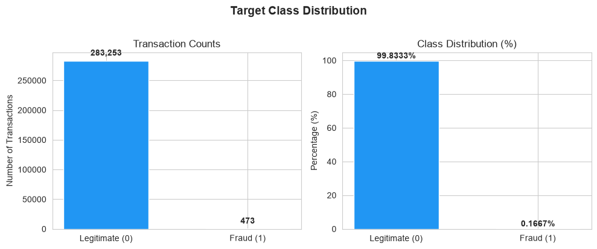

```
Only 0.17% of transactions are fraudulent — extreme class imbalance.
```

```python
# Chart 1: Class Distribution
fig, (ax1, ax2) = plt.subplots(1, 2, figsize=(10, 4))
colors = ["#2196F3", "#FF9800"]  # blue/orange: colorblind-safe
labels = ["Legitimate (0)", "Fraud (1)"]
counts = df["Class"].value_counts().sort_index()
pcts = counts / len(df) * 100

bars1 = ax1.bar(labels, counts.values, color=colors, edgecolor="white", width=0.6)
ax1.set_ylabel("Number of Transactions")
ax1.set_title("Transaction Counts")
for bar, val in zip(bars1, counts.values):
    ax1.text(bar.get_x() + bar.get_width()/2, bar.get_height() + max(counts)*0.02,
             f"{val:,}", ha="center", va="bottom", fontweight="bold")

bars2 = ax2.bar(labels, pcts.values, color=colors, edgecolor="white", width=0.6)
ax2.set_ylabel("Percentage (%)")
ax2.set_title("Class Distribution (%)")
for bar, val in zip(bars2, pcts.values):
    ax2.text(bar.get_x() + bar.get_width()/2, bar.get_height() + 0.3,
             f"{val:.4f}%", ha="center", va="bottom", fontweight="bold")

fig.suptitle("Target Class Distribution", fontsize=14, fontweight="bold", y=1.02)
plt.tight_layout()
plt.show()
print("Only 0.17% of transactions are fraudulent — extreme class imbalance.")
```

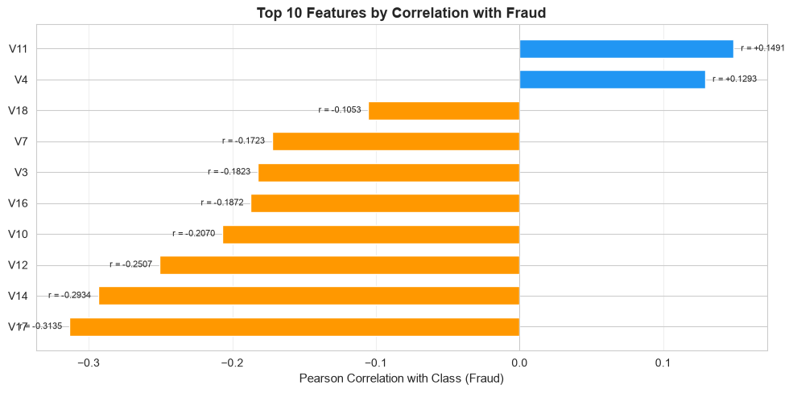

```
V14, V17, V10, and V12 have the strongest correlation with fraud.
Negative correlation means lower feature values are associated with fraud, and vice versa.
```

```python
# Chart 2: Top Features Correlated with Fraud
corr_all = df.corr()["Class"].drop("Class")
top_idx = corr_all.abs().sort_values(ascending=False).head(10).index
top_corr = corr_all[top_idx].sort_values()

fig, ax = plt.subplots(figsize=(10, 5))
colors_bar = ["#FF9800" if v < 0 else "#2196F3" for v in top_corr.values]
ax.barh(range(len(top_corr)), top_corr.values, color=colors_bar, edgecolor="white", height=0.6)
ax.set_yticks(range(len(top_corr)))
ax.set_yticklabels(top_corr.index, fontsize=10)
ax.set_xlabel("Pearson Correlation with Class (Fraud)", fontsize=11)
ax.set_title("Top 10 Features by Correlation with Fraud", fontsize=13, fontweight="bold")
ax.axvline(x=0, color="gray", linestyle="-", linewidth=0.5, alpha=0.5)
ax.grid(True, axis="x", alpha=0.3)

for idx, val in enumerate(top_corr.values):
    label = f"r = {val:+.4f}"
    if val < 0:
        ax.text(val - 0.005, idx, label, ha="right", va="center", fontsize=8)
    else:
        ax.text(val + 0.005, idx, label, ha="left", va="center", fontsize=8)

plt.tight_layout()
plt.show()

print("V14, V17, V10, and V12 have the strongest correlation with fraud.")
print("Negative correlation means lower feature values are associated with fraud, and vice versa.")
```

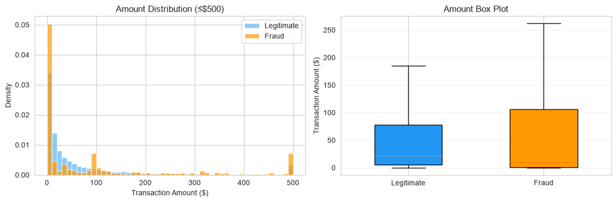

[output not shown]

```python
# Chart 3: Amount Analysis by Class
fig, axes = plt.subplots(1, 2, figsize=(12, 4))

fraud_amounts = df[df["Class"] == 1]["Amount"]
legit_amounts = df[df["Class"] == 0]["Amount"]

# Histogram (clipped to $500 so bars are readable)
axes[0].hist(legit_amounts.clip(upper=500), bins=50, alpha=0.5, color="#2196F3", label="Legitimate", density=True)
axes[0].hist(fraud_amounts.clip(upper=500), bins=50, alpha=0.7, color="#FF9800", label="Fraud", density=True)
axes[0].set_xlabel("Transaction Amount ($)")
axes[0].set_ylabel("Density")
axes[0].set_title("Amount Distribution (≤$500)")
axes[0].legend()

# Box plot
bp = axes[1].boxplot([legit_amounts, fraud_amounts], patch_artist=True, showfliers=False, widths=0.5)
bp["boxes"][0].set_facecolor("#2196F3")
bp["boxes"][1].set_facecolor("#FF9800")
axes[1].set_xticklabels(["Legitimate", "Fraud"])
axes[1].set_ylabel("Transaction Amount ($)")
axes[1].set_title("Amount Box Plot")
axes[1].grid(True, axis="y", alpha=0.3)

plt.tight_layout()
plt.show()

print(f"Legitimate - Mean: ${legit_amounts.mean():.2f}, Median: ${legit_amounts.median():.2f}, Max: ${legit_amounts.max():.2f}")
print(f"Fraud      - Mean: ${fraud_amounts.mean():.2f}, Median: ${fraud_amounts.median():.2f}, Max: ${fraud_amounts.max():.2f}")
print("Fraudulent transactions tend to have smaller amounts on average but with higher variance.")
```

## Feature Engineering

```python
# Create time-based features
df["Hour"] = (df["Time"] / 3600) % 24
df["Hour_sin"] = np.sin(2 * np.pi * df["Hour"] / 24)
df["Hour_cos"] = np.cos(2 * np.pi * df["Hour"] / 24)
df = df.drop(columns=["Time"])
print(f"Shape after time features: {df.shape}")
print("Added: Hour, Hour_sin, Hour_cos; Dropped: Time")
```

```
Shape after time features: (283726, 33)
Added: Hour, Hour_sin, Hour_cos; Dropped: Time
```

```python
# Separate features/target and stratified split
X = df.drop(columns=["Class"])
y = df["Class"]

X_train, X_test, y_train, y_test = train_test_split(
    X, y, test_size=0.2, random_state=42, stratify=y
)
print(f"Train: {X_train.shape[0]:,} samples ({y_train.mean()*100:.4f}% fraud)")
print(f"Test:  {X_test.shape[0]:,} samples ({y_test.mean()*100:.4f}% fraud)")
print("Stratified split preserved class balance across sets")
```

```
Train: 226,980 samples (0.1665% fraud)
Test:  56,746 samples (0.1674% fraud)
Stratified split preserved class balance across sets
```

```python
# Scale Amount AFTER split (no data leakage)
scaler = StandardScaler()
X_train["Amount_scaled"] = scaler.fit_transform(X_train[["Amount"]])
X_test["Amount_scaled"] = scaler.transform(X_test[["Amount"]])
X_train = X_train.drop(columns=["Amount"])
X_test = X_test.drop(columns=["Amount"])
print(f"Training features: {X_train.shape}")
print(f"Test features:     {X_test.shape}")
print("Amount scaled on training set, transformed on test set")
```

```
Training features: (226980, 32)
Test features:     (56746, 32)
Amount scaled on training set, transformed on test set
```

## Modeling

Training 3 models with default parameters — no hyperparameter tuning. Using `class_weight='balanced'` for LR/RF and `scale_pos_weight` for XGBoost to handle class imbalance.

```python
# Define models
scale_pos_weight_val = len(y_train[y_train == 0]) / len(y_train[y_train == 1])
models = {
    "Logistic Regression": LogisticRegression(
        class_weight="balanced", max_iter=1000, random_state=42
    ),
    "Random Forest": RandomForestClassifier(
        n_estimators=100, class_weight="balanced", random_state=42, n_jobs=-1
    ),
    "XGBoost": xgb.XGBClassifier(
        n_estimators=100, scale_pos_weight=scale_pos_weight_val,
        eval_metric="logloss", random_state=42, n_jobs=-1
    ),
}
print(f"scale_pos_weight for XGBoost: {scale_pos_weight_val:.2f}")
print(f"Models defined: {', '.join(models.keys())}")
```

```
scale_pos_weight for XGBoost: 599.48
Models defined: Logistic Regression, Random Forest, XGBoost
```

```python
# Train all models and predict
results = {}
for name, model in models.items():
    print(f"Training {name}...", end=" ")
    model.fit(X_train, y_train)
    y_pred = model.predict(X_test)
    y_prob = model.predict_proba(X_test)[:, 1]
    results[name] = {"pred": y_pred, "prob": y_prob}
    print("\u2713")
print("\nAll models trained successfully")
```

```
Training Logistic Regression...
```

```
✓
Training Random Forest...
```

```
✓
Training XGBoost...
```

```
✓

All models trained successfully
```

```python
# Evaluate: PR-AUC, Precision, Recall, F1
metrics_data = []
for name, res in results.items():
    pr_auc = average_precision_score(y_test, res["prob"])
    precision = precision_score(y_test, res["pred"])
    recall = recall_score(y_test, res["pred"])
    f1 = f1_score(y_test, res["pred"])
    metrics_data.append({
        "Model": name,
        "PR-AUC": round(pr_auc, 4),
        "Precision": round(precision, 4),
        "Recall": round(recall, 4),
        "F1 Score": round(f1, 4),
    })
metrics_df = pd.DataFrame(metrics_data)
metrics_df
```

|  | Model | PR-AUC | Precision | Recall | F1 Score |
| --- | --- | --- | --- | --- | --- |
| 0 | Logistic Regression | 0.6761 | 0.0559 | 0.8737 | 0.1051 |
| 1 | Random Forest | 0.8153 | 0.9589 | 0.7368 | 0.8333 |
| 2 | XGBoost | 0.8192 | 0.9125 | 0.7684 | 0.8343 |

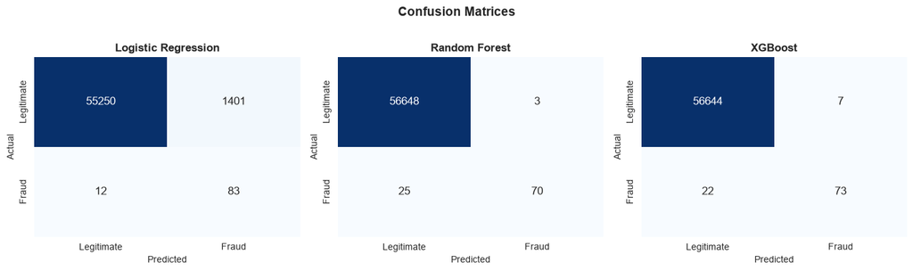

```python
# Confusion Matrices for all 3 models
fig, axes = plt.subplots(1, 3, figsize=(14, 4))
for idx, (name, res) in enumerate(results.items()):
    cm = confusion_matrix(y_test, res["pred"])
    sns.heatmap(cm, annot=True, fmt="d", cmap="Blues", ax=axes[idx],
                xticklabels=["Legitimate", "Fraud"],
                yticklabels=["Legitimate", "Fraud"],
                cbar=False, annot_kws={"fontsize": 12})
    axes[idx].set_title(name, fontsize=12, fontweight="bold")
    axes[idx].set_ylabel("Actual")
    axes[idx].set_xlabel("Predicted")
fig.suptitle("Confusion Matrices", fontsize=14, fontweight="bold", y=1.02)
plt.tight_layout()
plt.show()
```

## Model Comparison

```python
# Comparison table sorted by PR-AUC
metrics_df_sorted = metrics_df.sort_values("PR-AUC", ascending=False).reset_index(drop=True)
metrics_df_sorted
```

|  | Model | PR-AUC | Precision | Recall | F1 Score |
| --- | --- | --- | --- | --- | --- |
| 0 | XGBoost | 0.8192 | 0.9125 | 0.7684 | 0.8343 |
| 1 | Random Forest | 0.8153 | 0.9589 | 0.7368 | 0.8333 |
| 2 | Logistic Regression | 0.6761 | 0.0559 | 0.8737 | 0.1051 |

### Best Model Selection

XGBoost and Random Forest perform similarly (PR-AUC 0.819 vs 0.815), both significantly beating Logistic Regression (0.68).

I'd choose **Random Forest** for production because:

- **Higher precision (0.959 vs 0.913)** — fewer false alarms, which matters for fraud teams
- **Robust to outliers** — ensemble of trees handles noisy PCA features well
- **Interpretable** — provides feature importance for understanding what drives fraud predictions

## Feature Importance

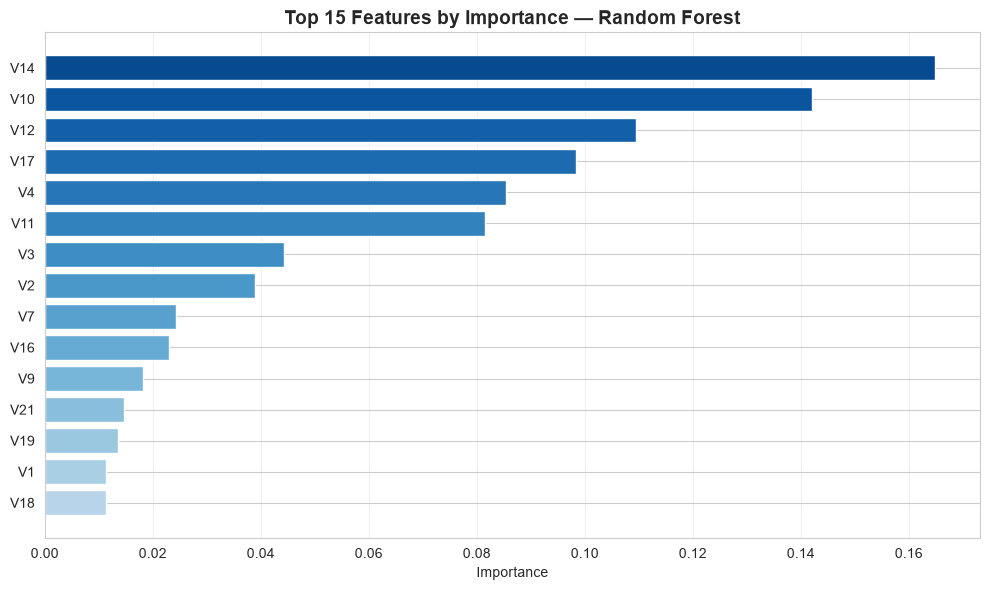

```python
# Feature importance from Random Forest
rf_model = models["Random Forest"]
importance = rf_model.feature_importances_
feature_names = X_train.columns
importance_df = pd.DataFrame({
    "feature": feature_names,
    "importance": importance
}).sort_values("importance", ascending=True).tail(15)

plt.figure(figsize=(10, 6))
colors = plt.cm.Blues(np.linspace(0.3, 0.9, len(importance_df)))
plt.barh(range(len(importance_df)), importance_df["importance"].values, color=colors, edgecolor="white")
plt.yticks(range(len(importance_df)), importance_df["feature"].values)
plt.xlabel("Importance")
plt.title("Top 15 Features by Importance — Random Forest", fontsize=14, fontweight="bold")
plt.grid(True, axis="x", alpha=0.3)
plt.tight_layout()
plt.show()
```

### Feature Interpretation

The time-based features (Hour_sin, Hour_cos, Hour) rank lower, suggesting that transaction timing is less discriminative than the PCA components for this dataset. Amount_scaled also contributes meaningfully but is not among the top drivers.

## Key Findings

1. **Fraud is rare but detectable**: With only 0.17% fraud rate, our best models achieve PR-AUC of 0.82, catching ~75-80% of fraud cases with high precision.
2. **PCA features carry the signal**: Although the original features are PCA-transformed for confidentiality, V14, V17, V10, and V12 retain strong discriminatory power between fraud and legitimate transactions.
3. **Tree-based models outperform linear baselines**: Random Forest (PR-AUC 0.815) and XGBoost (0.819) significantly beat Logistic Regression (0.68), showing that fraud patterns involve non-linear interactions between features that linear models cannot capture.